# Klasyfikacja liniowa

## Zadanie na 3

Porównanie sklearn i własnej implementacji klasyfikatora na syntetycznych zbiorach

#### Import bibliotek

```python
import numpy as np
import pandas as pd
from sklearn.datasets import make_classification
from sklearn.model_selection import train_test_split
from sklearn.metrics import confusion_matrix, ConfusionMatrixDisplay, roc_curve, auc, accuracy_score
import matplotlib.pyplot as plt
import time
import seaborn as sns
```

#### Funkcje do pomiaru skuteczności

plot_confusion_matrix -> macierz pomyłek

calculate_metrics -> Czułość (sensitivity) i swoistość (specificity).

plot_roc_curve -> wykres krzywej roc

```python
def plot_confusion_matrix(y_true, y_pred, labels=None):
    cm = confusion_matrix(y_true, y_pred)
    disp = ConfusionMatrixDisplay(confusion_matrix=cm, display_labels=labels)
    disp.plot(cmap="Blues", values_format="d")
    plt.title("Macierz Pomyłek")
    plt.show()


def calculate_metrics(y_true, y_pred):
    tn, fp, fn, tp = confusion_matrix(y_true, y_pred).ravel()
    sensitivity = tp / (tp + fn) if (tp + fn) > 0 else 0
    specificity = tn / (tn + fp) if (tn + fp) > 0 else 0
    return sensitivity, specificity

def plot_roc_curve(y_true, y_scores):
    fpr, tpr, _ = roc_curve(y_true, y_scores)
    roc_auc = auc(fpr, tpr)

    plt.figure(figsize=(8, 6))
    plt.plot(fpr, tpr, color='blue', label=f'ROC Curve (AUC = {roc_auc:.2f})')
    plt.plot([0, 1], [0, 1], color='red', linestyle='--', label='Losowa klasyfikacja')
    plt.xlabel('False Positive Rate (1 - Specificity)')
    plt.ylabel('True Positive Rate (Sensitivity)')
    plt.title('Krzywa ROC')
    plt.legend(loc='lower right')
    plt.grid()
    plt.show()
```

#### Generowanie zbioru danych

```python
my_index = 259199
my_n_samples = int(str(my_index)[0]+ str(my_index)[1] + str(my_index)[-2] + str(my_index)[-1])
X_raw, y_raw = make_classification(
    n_samples=my_n_samples,
    n_features=2,
    n_informative=2,
    n_redundant=0,
    n_clusters_per_class=1,
    random_state=my_index,
)

print('x', X_raw.shape)
print('y', y_raw.shape)
```

```
x (2599, 2)
y (2599,)
```

Dodanie baiasu, bo bez niego linia regresji zawsze przechodziłaby przez punkt (0,0), co nie jest pożądane w większości przypadków.

```python
X = np.hstack((np.ones((X_raw.shape[0], 1)), X_raw))
y = y_raw

print("X", X.shape)
print("y", y.shape)
```

```
X (2599, 3)
y (2599,)
```

#### Podział na zbiór treningowy i testowy

```python
X_train, X_test, y_train, y_test = train_test_split(X, y, test_size=0.2)

print('x', X_train.shape, X_test.shape)
print('y', y_train.shape, y_test.shape)
```

```
x (2079, 3) (520, 3)
y (2079,) (520,)
```

#### Implementacja analitycznej wersji klasyfikacji liniowej

Klasyfikacji liniowa z regularyzacją Tichonowa

```python
def train_tichonow(X_train, y_train, X_test, lambda_reg):
    y_train = np.where(y_train == 0, -1, 1)

    I = np.eye(X_train.shape[1])
    I[0, 0] = 0
    w = np.linalg.inv(X_train.T @ X_train + lambda_reg * I) @ X_train.T @ y_train

    y_pred = (X_test @ w > 0).astype(int)
    return y_pred, w
```

#### Implementacja przy użyciu Sklearn

sklearn.linear_model.RidgeClassifier

```python
from sklearn.linear_model import RidgeClassifier

def ridge_classifier(X_train, y_train, X_test, alpha=1.0):
    model = RidgeClassifier(alpha=alpha)
    model.fit(X_train, y_train)

    y_pred = model.predict(X_test)

    return y_pred
```

#### Porównanie czasów

Wywołanie obu funckji po 100 razy i zmierzenie czasów

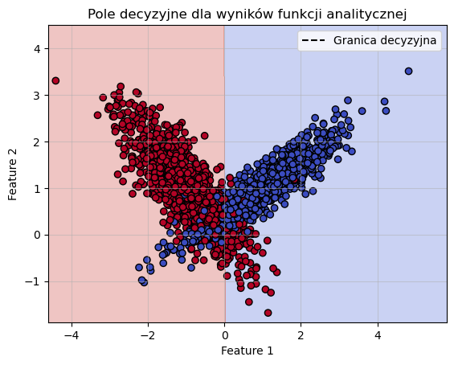

```
Tikhonov czas: 0.00850987434387207 s
Ridge czas: 0.13288474082946777 s
```

```python
X_train_copy = X_train.copy()
y_train_copy = y_train.copy()
X_test_copy = X_test.copy()
y_test_copy = y_test.copy()

start_time = time.time()
for i in range(100):
    _, w = train_tichonow(X_train_copy, y_train_copy, X_test_copy, 0.01)
end_time = time.time()

h = 0.01
x_min, x_max = X_train_copy[:, 1].min() - 0.2, X_train_copy[:, 1].max() + 1
y_min, y_max = X_train_copy[:, 2].min() - 0.2, X_train_copy[:, 2].max() + 1
xx, yy = np.meshgrid(np.arange(x_min, x_max, h),
                        np.arange(y_min, y_max, h))
grid_points = np.c_[xx.ravel(), yy.ravel()]
grid_points = np.hstack((np.ones((grid_points.shape[0], 1)), grid_points))
Z, w = train_tichonow(X_train_copy, y_train_copy, grid_points, 0.01)
Z = Z.reshape(xx.shape)

plt.contourf(xx, yy, Z, alpha=0.3, cmap=plt.cm.coolwarm)

plt.scatter(X_train_copy[:, 1], X_train_copy[:, 2], c=y_train, edgecolors='k', cmap=plt.cm.coolwarm)
plt.xlabel("Feature 1")
plt.ylabel("Feature 2")
plt.grid(alpha=0.5)

x_vals = np.linspace(X_train_copy[:, 1].min() - 0.2, X_train_copy[:, 2].max() + 0.2, 100)
bias, w1, w2= w
y_vals = -(bias + w1 * x_vals) / w2

y_min, y_max = X_train_copy[:, 1].min() - 0.2, X_train_copy[:, 1].max() + 0.2
mask = (y_vals >= y_min) & (y_vals <= y_max)
x_vals = x_vals[mask]
y_vals = y_vals[mask]
plt.plot(x_vals, y_vals, 'k--', label='Granica decyzyjna')

plt.legend()
plt.title("Pole decyzyjne dla wyników funkcji analitycznej")
plt.show()

print("Tikhonov czas:", end_time - start_time, "s")

start_time = time.time()
for _ in range(100):
    _ = ridge_classifier(X_train_copy, y_train_copy, X_test_copy, alpha=0.01)
end_time = time.time()

print("Ridge czas:", end_time - start_time, "s")
```

#### Porównanie wyników

```
Tikhonov - Czułość: 90.94%, Swoistość: 82.35%
```

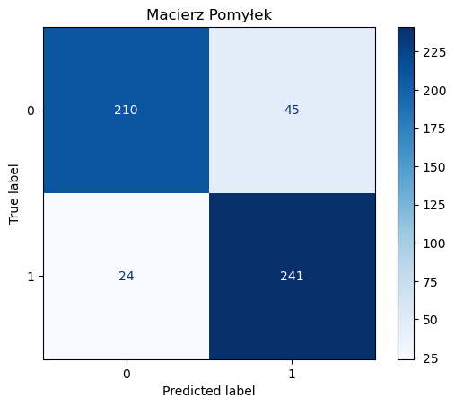

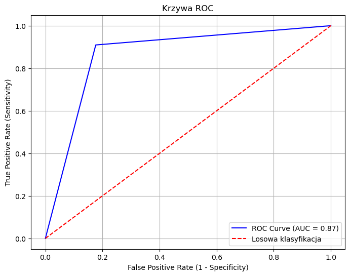

```
RidgeClassifier - Czułość: 90.94%, Swoistość: 82.35%
```

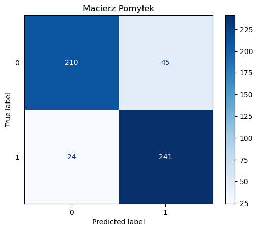

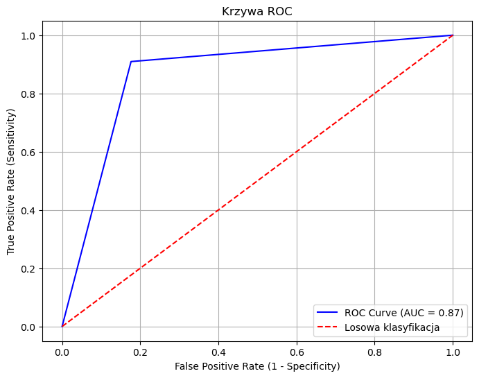

```python
lambda_reg = 1
y_pred = ridge_classifier(X_train, y_train, X_test, alpha=lambda_reg)
y_pred_tikhonov, _ = train_tichonow(X_train, y_train, X_test, lambda_reg)

sensitivity_tikhonov, specificity_tikhonov = calculate_metrics(y_test, y_pred_tikhonov)
print(f"Tikhonov - Czułość: {sensitivity_tikhonov * 100:.2f}%, Swoistość: {specificity_tikhonov * 100:.2f}%")
plot_confusion_matrix(y_test, y_pred_tikhonov, labels=[0, 1])
plot_roc_curve(y_test, y_pred_tikhonov)

sensitivity_ridge, specificity_ridge = calculate_metrics(y_test, y_pred)
print(f"RidgeClassifier - Czułość: {sensitivity_ridge * 100:.2f}%, Swoistość: {specificity_ridge * 100:.2f}%")
plot_confusion_matrix(y_test, y_pred, labels=[0, 1])
plot_roc_curve(y_test, y_pred)
```

### Generowanie drugiego zbioru danych

Wygenerowanie zbioru danych przy użyciu make_moons.

```python
from sklearn.datasets import make_moons

X_raw_moons, y_raw_moons = make_moons(n_samples=my_n_samples, noise=0.2, random_state=my_index)

print('X_moons', X_raw_moons.shape)
print('y_moons', y_raw_moons.shape)
```

```
X_moons (2599, 2)
y_moons (2599,)
```

Dodanie biasu do zbioru make_moons.

```python
X_moons = np.hstack((np.ones((X_raw_moons.shape[0], 1)), X_raw_moons))
y_moons = y_raw_moons

print("X_moons", X_moons.shape)
print("y_moons", y_moons.shape)
```

```
X_moons (2599, 3)
y_moons (2599,)
```

Podział zbioru make_moons na zbiór treningowy i testowy.

```python
X_train_moons, X_test_moons, y_train_moons, y_test_moons = train_test_split(X_moons, y_moons, test_size=0.2)

print('X_train_moons', X_train_moons.shape, 'X_test_moons', X_test_moons.shape)
print('y_train_moons', y_train_moons.shape, 'y_test_moons', y_test_moons.shape)
```

```
X_train_moons (2079, 3) X_test_moons (520, 3)
y_train_moons (2079,) y_test_moons (520,)
```

#### Porównanie klasyfikatorów na zbiorze make_moons

```
RidgeClassifier (make_moons) - Czułość: 86.25%, Swoistość: 86.06%
```

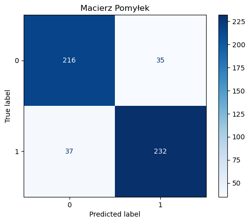

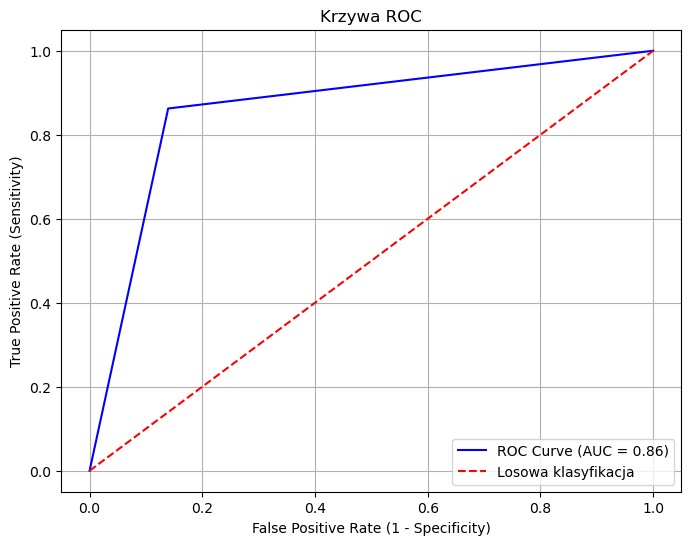

```
Tikhonov (make_moons) - Czułość: 86.25%, Swoistość: 86.06%
```

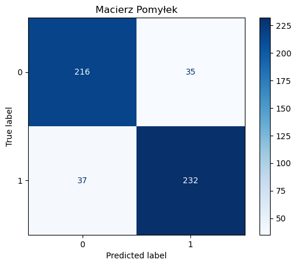

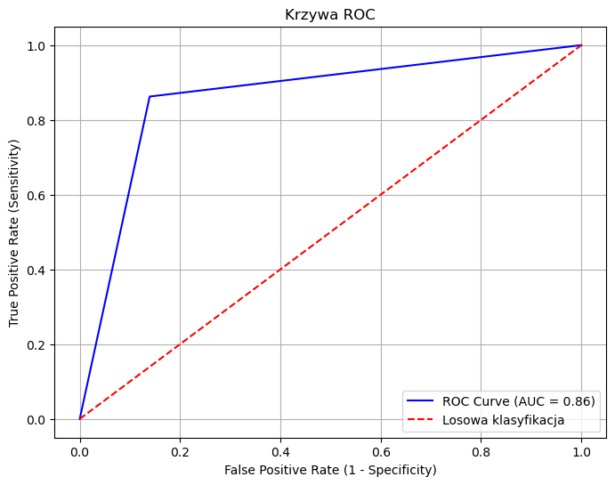

```python
lambda_reg = 1

# RidgeClassifier on make_moons
y_pred_moons = ridge_classifier(X_train_moons, y_train_moons, X_test_moons, alpha=lambda_reg)
sensitivity_ridge_moons, specificity_ridge_moons = calculate_metrics(y_test_moons, y_pred_moons)
print(f"RidgeClassifier (make_moons) - Czułość: {sensitivity_ridge_moons * 100:.2f}%, Swoistość: {specificity_ridge_moons * 100:.2f}%")
plot_confusion_matrix(y_test_moons, y_pred_moons, labels=[0, 1])
plot_roc_curve(y_test_moons, y_pred_moons)

# Tikhonov on make_moons
y_pred_tikhonov_moons, _ = train_tichonow(X_train_moons, y_train_moons, X_test_moons, lambda_reg)
sensitivity_tikhonov_moons, specificity_tikhonov_moons = calculate_metrics(y_test_moons, y_pred_tikhonov_moons)
print(f"Tikhonov (make_moons) - Czułość: {sensitivity_tikhonov_moons * 100:.2f}%, Swoistość: {specificity_tikhonov_moons * 100:.2f}%")
plot_confusion_matrix(y_test_moons, y_pred_tikhonov_moons, labels=[0, 1])
plot_roc_curve(y_test_moons, y_pred_tikhonov_moons)
```

#### Porównanie czasów dla zbioru make_moons

```python
start_time = time.time()
for _ in range(100):
    _ = train_tichonow(X_train_moons, y_train_moons, X_test_moons, lambda_reg=0.01)
end_time = time.time()
print("Tikhonov czas (make_moons):", end_time - start_time, "s")

start_time = time.time()
for _ in range(100):
    _ = ridge_classifier(X_train_moons, y_train_moons, X_test_moons, alpha=0.01)
end_time = time.time()
print("Ridge czas (make_moons):", end_time - start_time, "s")
```

```
Tikhonov czas (make_moons): 0.008781194686889648 s
Ridge czas (make_moons): 0.13524627685546875 s
```

#### Wyniki zbiorcze

Porównanie swoistości i czułości różnych algorytmów na różnych zbiorach danych.

```python
results_summary = pd.DataFrame({
    "Zbiór danych": ["make_classification", "make_classification", "make_moons", "make_moons"],
    "Algorytm": ["RidgeClassifier", "Tikhonov", "RidgeClassifier", "Tikhonov"],
    "Czułość (%)": [
        sensitivity_ridge * 100,
        sensitivity_tikhonov * 100,
        sensitivity_ridge_moons * 100,
        sensitivity_tikhonov_moons * 100
    ],
    "Swoistość (%)": [
        specificity_ridge * 100,
        specificity_tikhonov * 100,
        specificity_ridge_moons * 100,
        specificity_tikhonov_moons * 100
    ]
})

print(results_summary)
```

```
          Zbiór danych         Algorytm  Czułość (%)  Swoistość (%)
0  make_classification  RidgeClassifier    90.943396      82.352941
1  make_classification         Tikhonov    90.943396      82.352941
2           make_moons  RidgeClassifier    86.245353      86.055777
3           make_moons         Tikhonov    86.245353      86.055777
```

#### Wnioski

- Ridge klasyfikator jest wolniejszy od analitycznej wersji klasyfikacji

## Zadanie na 4

Eksploracja danych i uzasadniona odpowiedź na pytanie

#### Pobranie danych

```python
file_path = f'./datasets/HeartCleveland.csv'
data = pd.read_csv(file_path, header=None)
data.replace('?', np.nan, inplace=True)
data = data.apply(pd.to_numeric)

print(data.head(), data.shape)
```

```
     0    1    2      3      4    5    6      7    8    9    10   11   12  13
0  63.0  1.0  1.0  145.0  233.0  1.0  2.0  150.0  0.0  2.3  3.0  0.0  6.0   0
1  67.0  1.0  4.0  160.0  286.0  0.0  2.0  108.0  1.0  1.5  2.0  3.0  3.0   2
2  67.0  1.0  4.0  120.0  229.0  0.0  2.0  129.0  1.0  2.6  2.0  2.0  7.0   1
3  37.0  1.0  3.0  130.0  250.0  0.0  0.0  187.0  0.0  3.5  3.0  0.0  3.0   0
4  41.0  0.0  2.0  130.0  204.0  0.0  2.0  172.0  0.0  1.4  1.0  0.0  3.0   0 (303, 14)
```

Zamiana Y na wartości binarne

```python
nan_rows_count = data.isna().any(axis=1).sum()
print(f"Liczba wierszy z wartościami NaN: {nan_rows_count}")

data = data.dropna()
data.iloc[:, -1] = (data.iloc[:, -1] > 0).astype(int)

print(data.shape)
print(data.head())
```

```
Liczba wierszy z wartościami NaN: 6
(297, 14)
     0    1    2      3      4    5    6      7    8    9    10   11   12  13
0  63.0  1.0  1.0  145.0  233.0  1.0  2.0  150.0  0.0  2.3  3.0  0.0  6.0   0
1  67.0  1.0  4.0  160.0  286.0  0.0  2.0  108.0  1.0  1.5  2.0  3.0  3.0   1
2  67.0  1.0  4.0  120.0  229.0  0.0  2.0  129.0  1.0  2.6  2.0  2.0  7.0   1
3  37.0  1.0  3.0  130.0  250.0  0.0  0.0  187.0  0.0  3.5  3.0  0.0  3.0   0
4  41.0  0.0  2.0  130.0  204.0  0.0  2.0  172.0  0.0  1.4  1.0  0.0  3.0   0
```

#### Podział danych na cechy i etykiety

```python
X = data.iloc[:, :-1]
y = data.iloc[:, -1]

print("X shape:", X.shape)
print("y shape:", y.shape)
```

```
X shape: (297, 13)
y shape: (297,)
```

#### Obliczanie podstawowych miar statystycznych

```python
stats = []
for column in X.columns:
    mean = data[column].mean()
    mode = data[column].mode()[0]
    std_dev = data[column].std()
    min_val = data[column].min()
    max_val = data[column].max()
    unique_values = data[column].nunique()
    total_values = len(data[column])
    feature_type = "Kategoryczna" if unique_values / total_values < 0.05 else "Ciągła"

    stats.append({
        "Cecha": column,
        "Średnia": mean,
        "Dominanta": mode,
        "Odchylenie standardowe": std_dev,
        "Minimum": min_val,
        "Maksimum": max_val,
        "Typ cechy": feature_type
    })

print(pd.DataFrame(stats))
```

```
    Cecha     Średnia  Dominanta  Odchylenie standardowe  Minimum  Maksimum  \
0       0   54.542088       58.0                9.049736     29.0      77.0
1       1    0.676768        1.0                0.468500      0.0       1.0
2       2    3.158249        4.0                0.964859      1.0       4.0
3       3  131.693603      120.0               17.762806     94.0     200.0
4       4  247.350168      197.0               51.997583    126.0     564.0
5       5    0.144781        0.0                0.352474      0.0       1.0
6       6    0.996633        0.0                0.994914      0.0       2.0
7       7  149.599327      162.0               22.941562     71.0     202.0
8       8    0.326599        0.0                0.469761      0.0       1.0
9       9    1.055556        0.0                1.166123      0.0       6.2
10     10    1.602694        1.0                0.618187      1.0       3.0
11     11    0.676768        0.0                0.938965      0.0       3.0
12     12    4.730640        3.0                1.938629      3.0       7.0

       Typ cechy
0         Ciągła
1   Kategoryczna
2   Kategoryczna
3         Ciągła
4         Ciągła
5   Kategoryczna
6   Kategoryczna
7         Ciągła
8   Kategoryczna
9         Ciągła
10  Kategoryczna
11  Kategoryczna
12  Kategoryczna
```

#### Histogramy

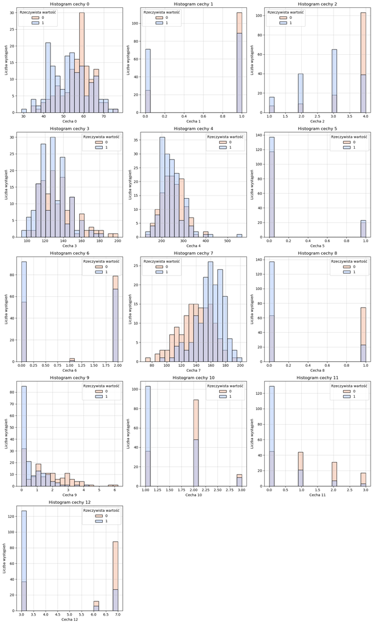

```python
num_features = X.shape[1]
rows = (num_features + 2) // 3
fig, axes = plt.subplots(rows, 3, figsize=(15, 5 * rows))

for idx, ax in enumerate(axes.flat):
    if idx < num_features:
        sns.histplot(data=data, x=idx, hue=y, kde=False, palette="coolwarm", bins=20, ax=ax)
        ax.set_title(f"Histogram cechy {idx}")
        ax.set_xlabel(f"Cecha {idx}")
        ax.set_ylabel("Liczba wystąpień")
        ax.legend(title="Rzeczywista wartość", labels=["0", "1"])
        ax.grid(alpha=0.5)
    else:
        ax.axis('off')

plt.tight_layout()
plt.show()
```

#### Obliczenie i wyświetlenie macierzy korelacji

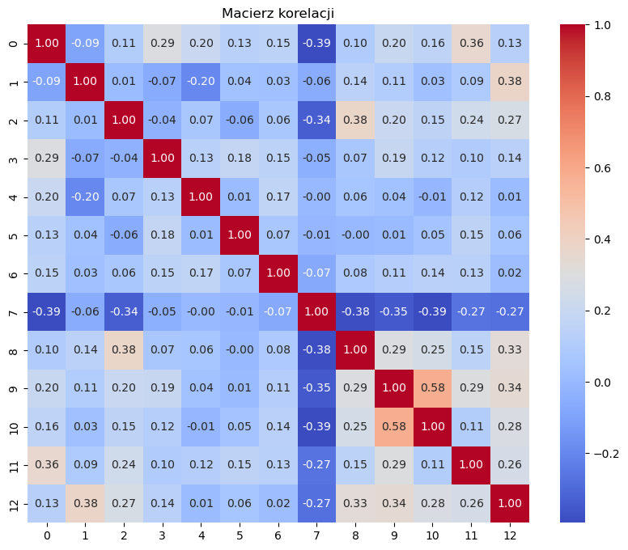

```python
import seaborn as sns

correlation_matrix = X.corr()

plt.figure(figsize=(10, 8))
sns.heatmap(correlation_matrix, annot=True, fmt=".2f", cmap="coolwarm", cbar=True)
plt.title("Macierz korelacji")
plt.show()
```

#### Wybrane 4 cechy

Cechy o indeksach 3, 6, 8, 11

- niska korelacja cech między sobą
- wysoka różnorodność
- niska redundantność - niska powtarzalność lub duplikowanie informacji

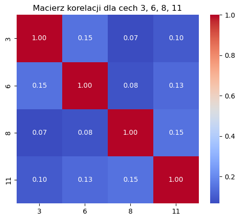

```python
selected_features = [3, 6, 8, 11]
selected_correlation_matrix = correlation_matrix.loc[selected_features, selected_features]

plt.figure(figsize=(6, 5))
sns.heatmap(selected_correlation_matrix, annot=True, fmt=".2f", cmap="coolwarm", cbar=True)
plt.title("Macierz korelacji dla cech 3, 6, 8, 11")
plt.show()
```

## Zadanie na 5

Porównanie sklearn i własnej implementacji na zbiorze o chorobach serca i różnych zestawach cech

#### Normalizacja danych

```python
from sklearn.preprocessing import MinMaxScaler

scaler = MinMaxScaler(feature_range=(-1, 1))
X = scaler.fit_transform(X)

print(pd.DataFrame(X).head())
```

```
         0    1         2         3         4    5    6         7    8   \
0  0.416667  1.0 -1.000000 -0.037736 -0.511416  1.0  1.0  0.206107 -1.0
1  0.583333  1.0  1.000000  0.245283 -0.269406 -1.0  1.0 -0.435115  1.0
2  0.583333  1.0  1.000000 -0.509434 -0.529680 -1.0  1.0 -0.114504  1.0
3 -0.666667  1.0  0.333333 -0.320755 -0.433790 -1.0 -1.0  0.770992 -1.0
4 -0.500000 -1.0 -0.333333 -0.320755 -0.643836 -1.0  1.0  0.541985 -1.0

         9    10        11   12
0 -0.258065  1.0 -1.000000  0.5
1 -0.516129  0.0  1.000000 -1.0
2 -0.161290  0.0  0.333333  1.0
3  0.129032  1.0 -1.000000 -1.0
4 -0.548387 -1.0 -1.000000 -1.0
```

#### Podział danych na treningowe i testowe

```python
X_train, X_test, y_train, y_test = train_test_split(X, y, test_size=0.2)

print('x', X_train.shape, X_test.shape)
print('y', y_train.shape, y_test.shape)
```

```
x (237, 13) (60, 13)
y (237,) (60,)
```

#### Porównanie klasyfikatorów na zbiorze danych wykorzystując 13 głównych cech

```
RidgeClassifier - czas dla 100 iteracji: 0.11 s
RidgeClassifier - Czułość: 68.97%, Swoistość: 90.32%
```

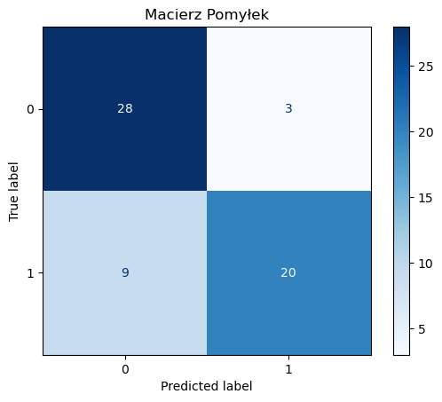

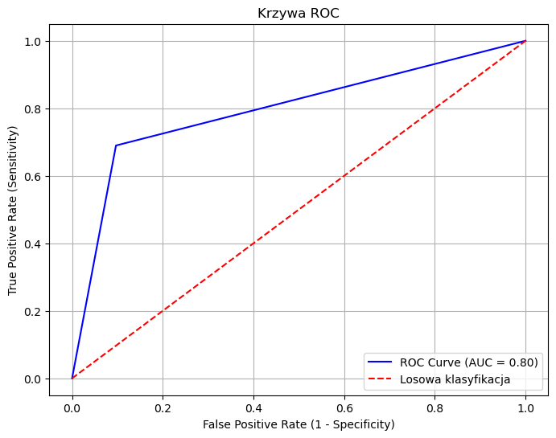

```
Tikhonov - czas dla 100 iteracji: 0.02 s
Tikhonov - Czułość: 65.52%, Swoistość: 93.55%
```

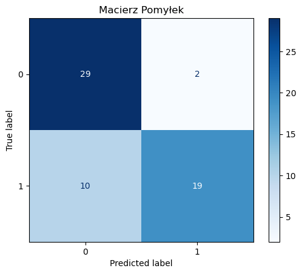

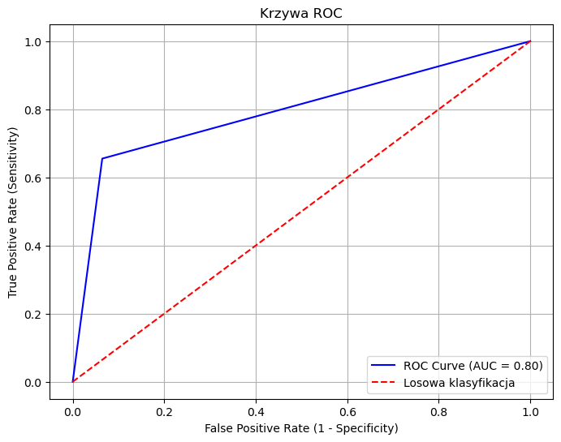

```python
start_time = time.time()
for _ in range(100):
    ridge_pred = ridge_classifier(X_train, y_train, X_test, alpha=1.0)
end_time = time.time()
print(f"RidgeClassifier - czas dla 100 iteracji: {end_time - start_time:.2f} s")

ridge_sensitivity, ridge_specificity = calculate_metrics(y_test, ridge_pred)

print(f"RidgeClassifier - Czułość: {ridge_sensitivity * 100:.2f}%, Swoistość: {ridge_specificity * 100:.2f}%")
plot_confusion_matrix(y_test, ridge_pred, labels=[0, 1])
plot_roc_curve(y_test, ridge_pred)

start_time = time.time()
for _ in range(100):
    tikhonov_pred, _ = train_tichonow(X_train, y_train, X_test, lambda_reg=1.0)
end_time = time.time()
print(f"Tikhonov - czas dla 100 iteracji: {end_time - start_time:.2f} s")

tikhonov_sensitivity, tikhonov_specificity = calculate_metrics(y_test, tikhonov_pred)

print(f"Tikhonov - Czułość: {tikhonov_sensitivity * 100:.2f}%, Swoistość: {tikhonov_specificity * 100:.2f}%")
plot_confusion_matrix(y_test, tikhonov_pred, labels=[0, 1])
plot_roc_curve(y_test, tikhonov_pred)
```

### Automatyczny wybór 4 cech

W oparciu o RidgeClassifier z sklearn i sklearn.feature_selection.SequentialFeatureSelector wybrane 4 najlepsze cechy

```python
from sklearn.feature_selection import SequentialFeatureSelector
from sklearn.linear_model import RidgeClassifier

ridge_model = RidgeClassifier(alpha=1.0)
sfs = SequentialFeatureSelector(ridge_model, n_features_to_select=4, direction='forward')
sfs.fit(X, y)

selected_features = sfs.get_support(indices=True)
print("Wybrane cechy:", selected_features)
```

```
Wybrane cechy: [ 7  8 11 12]
```

#### Podział danych na używające tylko danych cech

```python
x_test_automatic = X_test[:, selected_features]
x_train_automatic = X_train[:, selected_features]

my_selected_features = [3, 6, 8, 11]

x_test_manual = X_test[:, my_selected_features]
x_train_manual = X_train[:, my_selected_features]

print("Automatyczne: ", x_train_automatic.shape, x_test_automatic.shape)
print("Manulane: ", x_train_manual.shape, x_test_manual.shape)
```

```
Automatyczne:  (237, 4) (60, 4)
Manulane:  (237, 4) (60, 4)
```

#### Porównanie klasyfikatorów na zbiorze danych wykorzystując 4 cechy

Cechy automatyczne

```
Automatyczne cechy - RidgeClassifier - Czułość: 75.86%, Swoistość: 90.32%
```

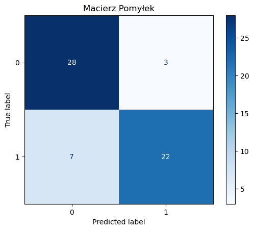

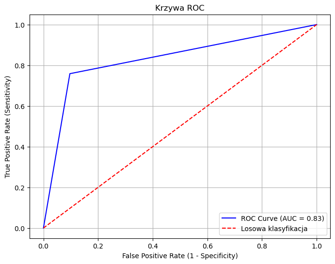

```
Automatyczne cechy - Tikhonov - Czułość: 55.17%, Swoistość: 90.32%
```

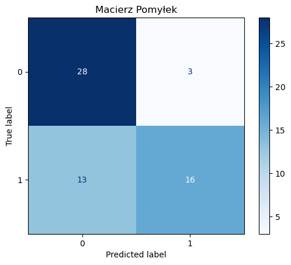

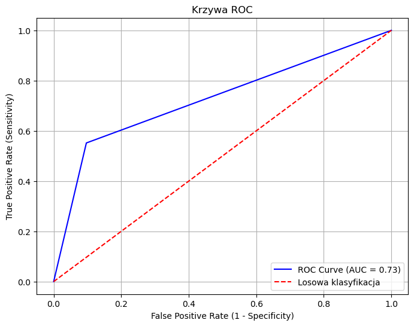

```python
ridge_pred_auto = ridge_classifier(x_train_automatic, y_train, x_test_automatic, alpha=1.0)
tikhonov_pred_auto, _ = train_tichonow(x_train_automatic, y_train, x_test_automatic, lambda_reg=1.0)

ridge_sensitivity_auto, ridge_specificity_auto = calculate_metrics(y_test, ridge_pred_auto)
tikhonov_sensitivity_auto, tikhonov_specificity_auto = calculate_metrics(y_test, tikhonov_pred_auto)

print(f"Automatyczne cechy - RidgeClassifier - Czułość: {ridge_sensitivity_auto * 100:.2f}%, Swoistość: {ridge_specificity_auto * 100:.2f}%")
plot_confusion_matrix(y_test, ridge_pred_auto, labels=[0, 1])
plot_roc_curve(y_test, ridge_pred_auto)

print(f"Automatyczne cechy - Tikhonov - Czułość: {tikhonov_sensitivity_auto * 100:.2f}%, Swoistość: {tikhonov_specificity_auto * 100:.2f}%")
plot_confusion_matrix(y_test, tikhonov_pred_auto, labels=[0, 1])
plot_roc_curve(y_test, tikhonov_pred_auto)
```

Cechy wybrane samodzielnie

```
Manualne cechy - RidgeClassifier - Czułość: 68.97%, Swoistość: 80.65%
```

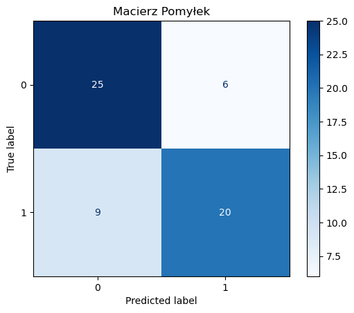

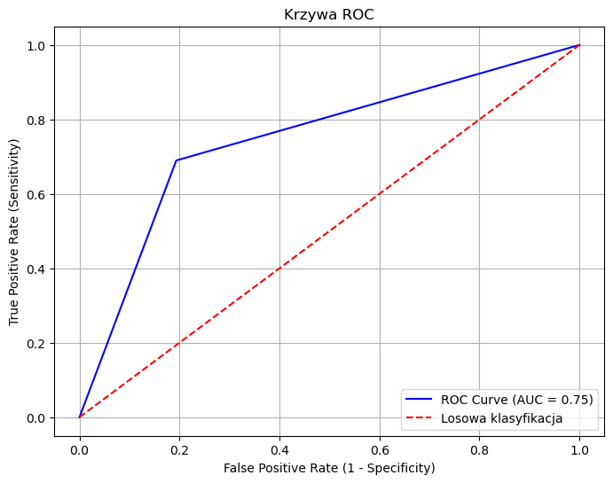

```
Manualne cechy - Tikhonov - Czułość: 58.62%, Swoistość: 87.10%
```

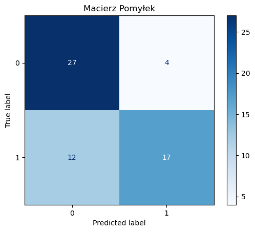

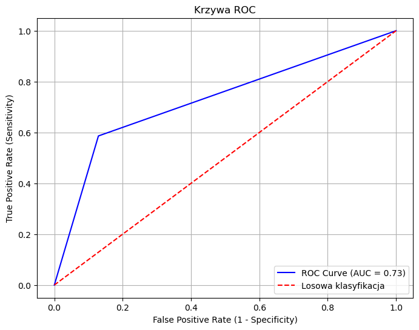

```python
ridge_pred_manual = ridge_classifier(x_train_manual, y_train, x_test_manual, alpha=1.0)
tikhonov_pred_manual, _ = train_tichonow(x_train_manual, y_train, x_test_manual, lambda_reg=1.0)

ridge_sensitivity_manual, ridge_specificity_manual = calculate_metrics(y_test, ridge_pred_manual)
tikhonov_sensitivity_manual, tikhonov_specificity_manual = calculate_metrics(y_test, tikhonov_pred_manual)

print(f"Manualne cechy - RidgeClassifier - Czułość: {ridge_sensitivity_manual * 100:.2f}%, Swoistość: {ridge_specificity_manual * 100:.2f}%")
plot_confusion_matrix(y_test, ridge_pred_manual, labels=[0, 1])
plot_roc_curve(y_test, ridge_pred_manual)

print(f"Manualne cechy - Tikhonov - Czułość: {tikhonov_sensitivity_manual * 100:.2f}%, Swoistość: {tikhonov_specificity_manual * 100:.2f}%")
plot_confusion_matrix(y_test, tikhonov_pred_manual, labels=[0, 1])
plot_roc_curve(y_test, tikhonov_pred_manual)
```

```python
ridge_accuracy_auto = accuracy_score(y_test, ridge_pred_auto)
ridge_accuracy_manual = accuracy_score(y_test, ridge_pred_manual)

ridge_precision_auto = np.sum((ridge_pred_auto == 1) & (y_test == 1)) / np.sum(ridge_pred_auto == 1)
ridge_precision_manual = np.sum((ridge_pred_manual == 1) & (y_test == 1)) / np.sum(ridge_pred_manual == 1)

results = pd.DataFrame({
    "Metryka": ["Dokładność", "Precyzja", "Czułość", "Swoistość"],
    "Automatyczne cechy (%)": [ridge_accuracy_auto * 100, ridge_precision_auto * 100, ridge_sensitivity_auto * 100, ridge_specificity_auto * 100],
    "Manualne cechy (%)": [ridge_accuracy_manual * 100, ridge_precision_manual * 100, ridge_sensitivity_manual * 100, ridge_specificity_manual * 100]
})

print(results)
```

```
      Metryka  Automatyczne cechy (%)  Manualne cechy (%)
0  Dokładność               83.333333           75.000000
1    Precyzja               88.000000           76.923077
2     Czułość               75.862069           68.965517
3   Swoistość               90.322581           80.645161
```